# Minimal Residual Disease in ALL – First Round Survey Results

# 19 Technical Requirements RNA-based BCR::ABL1 qPCR

## 19.1 Which anticoagulant do you use for bone marrow samples intended for BCR::ABL1-based qPCR MRD analysis?

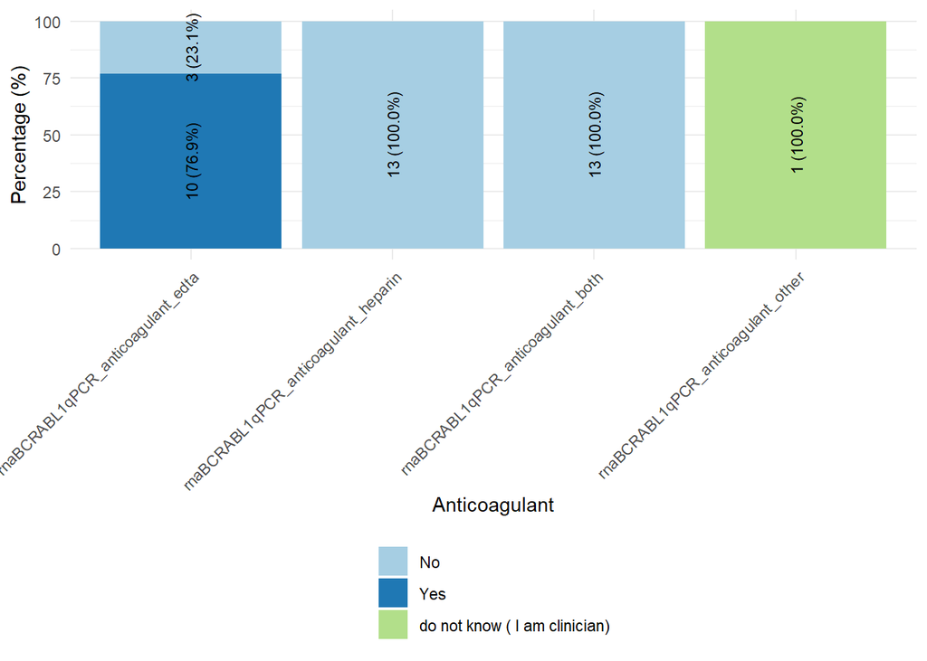

## 19.2 Which housekeeping gene do you use for BCR::ABL1 qPCR normalization?

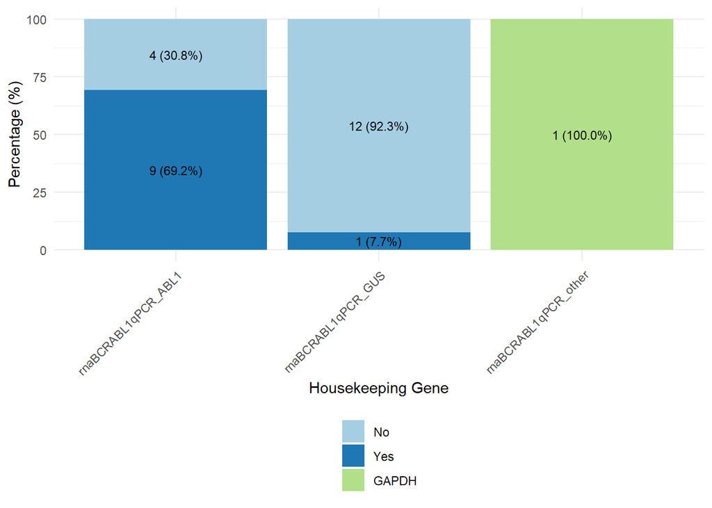

## 19.3 How many copies of the housekeeping gene do you typically aim for in BCR::ABL1 transcript quantification?

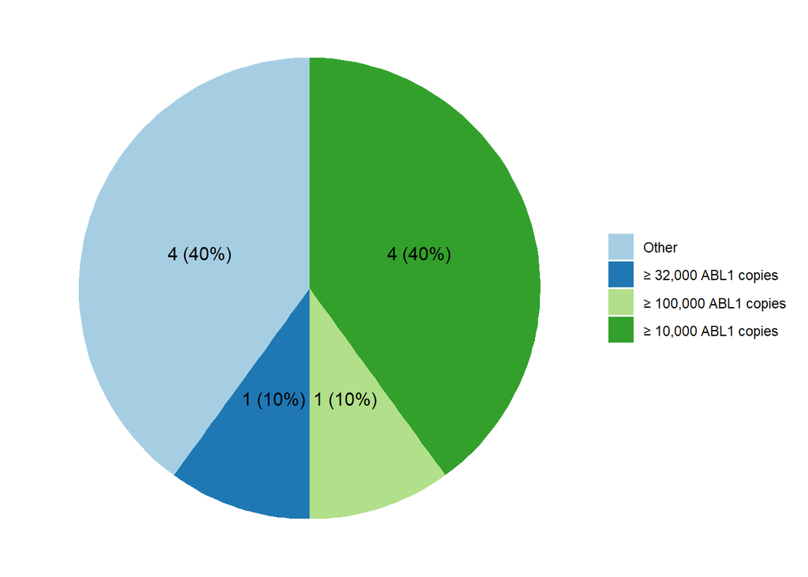

| Category | Comment |
| --- | --- |
| NA | do not know ( I am clinician) |
| Other | aim for >100,000 ABL1 copies |
| Other | NA (Cepheid) |
| Other | depends on situation, in poor samples we use bad quality samples and comment |
| Other | 15-35 copies GAPDH |

## 19.4 How do you quantify the housekeeping gene as the denominator for BCR::ABL1 MRD assessment:

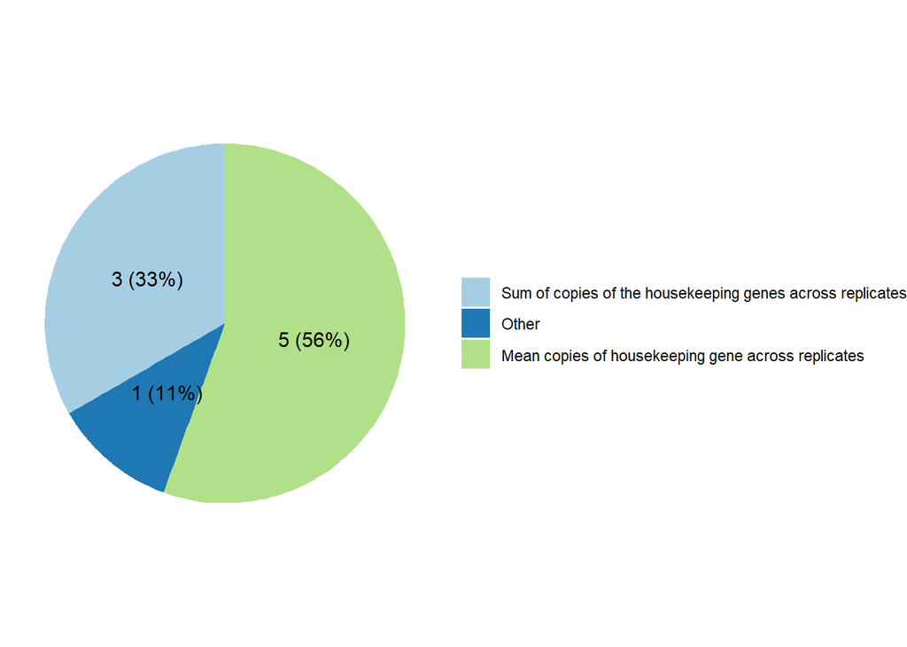

| Category | Comment |
| --- | --- |
| NA | do not know ( I am clinician) |
| Other | cepheid |

## 19.5 What is the source of the plasmids you use for BCR::ABL1 quantification?

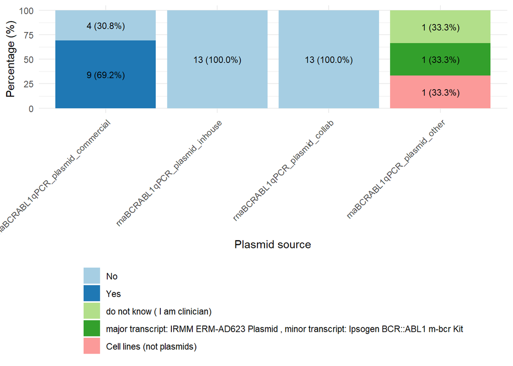

## 19.6 How do you report the MRD value for the major BCR::ABL1 transcripts?

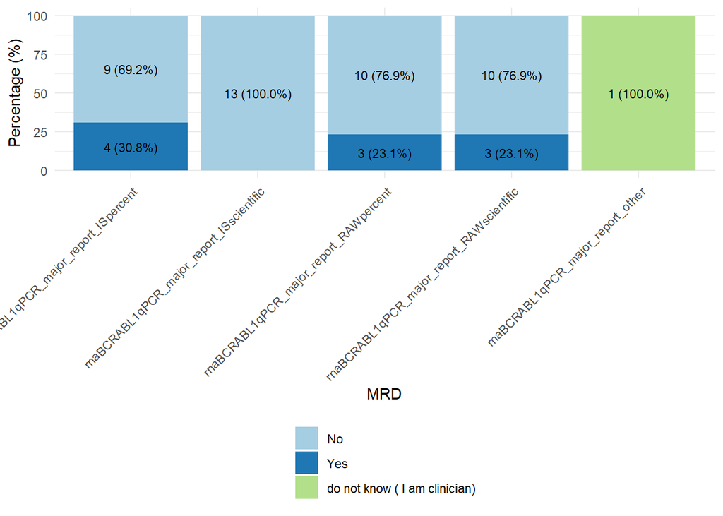

## 19.7 What is the minimum number of positive replicates required to define MRD positivity?

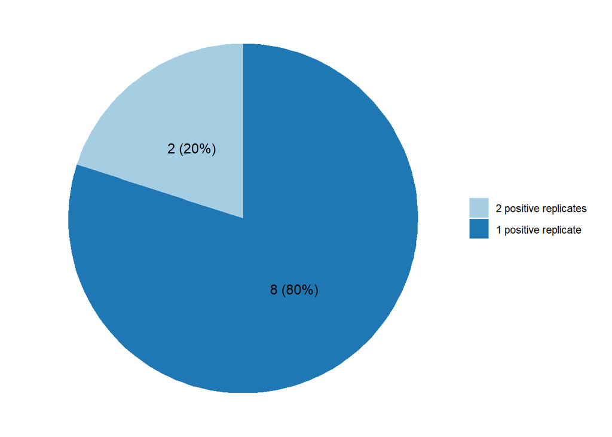

| Category | Comment |
| --- | --- |
| NA | do not know ( I am clinician) |

## 19.8 How do you report the MRD value for the minor BCR::ABL1 transcripts?

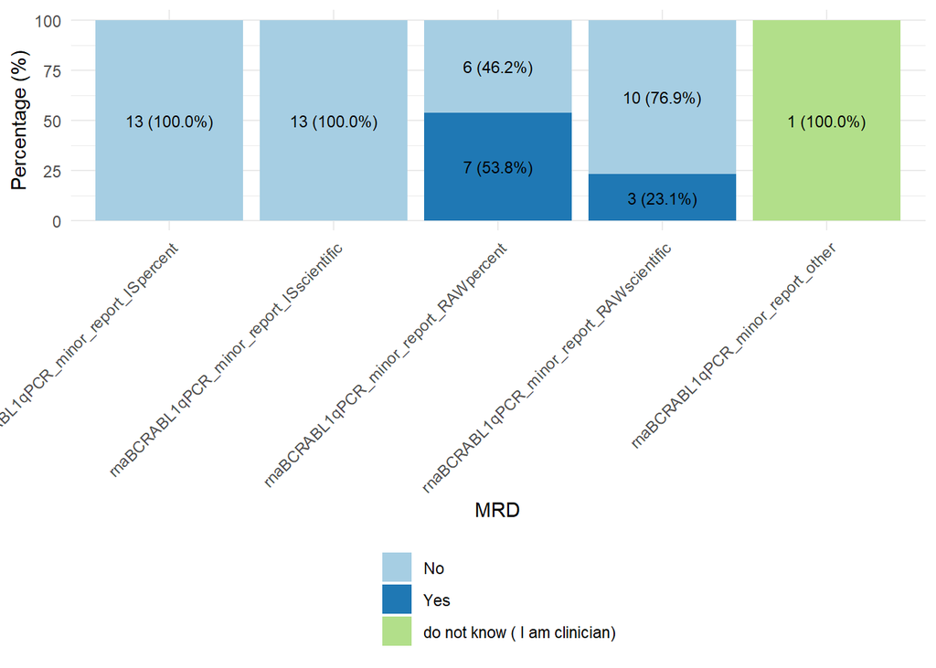

## 19.9 Do you use the CML MRD nomenclature to interpret BCR::ABL1-MRD results in Ph+ ALL (MMR, MR4, MR4.5, MR5)?

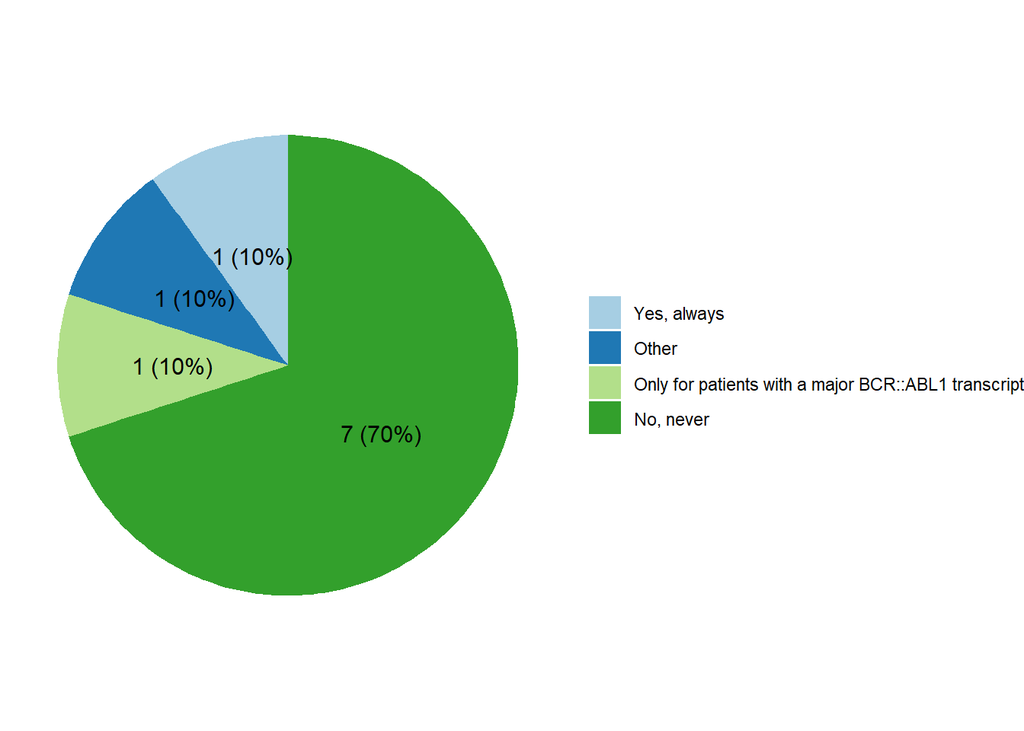

| Category | Comment |
| --- | --- |
| NA | do not know ( I am clinician) |
| Other | Only if a clinical trial asks us to do so |

## 19.10 Do you use a commercial assay or an in-house assay for **major** BCR::ABL1-transcript-based MRD analysis?

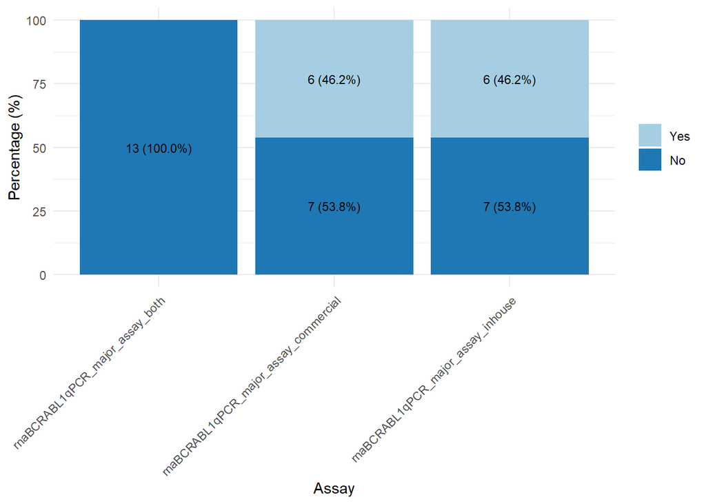

| Category | Comment |
| --- | --- |
| Commercial | Cepheid |
| Commercial | Qiagene |
| Commercial | Xpert BCR-ABL ULTRA (Cepheid) |
| Commercial | commercial for CML |
| In-house | IRMM ERM-AD623 Plasmid and in-house assay |
| In-house | in house for MRD in Ph+ ALL |
| In-house | EAC Priimer- Probe Set |

## 19.11 Do you use a commercial assay or an in-house assay for **minor** BCR::ABL1-transcript-based MRD analysis?

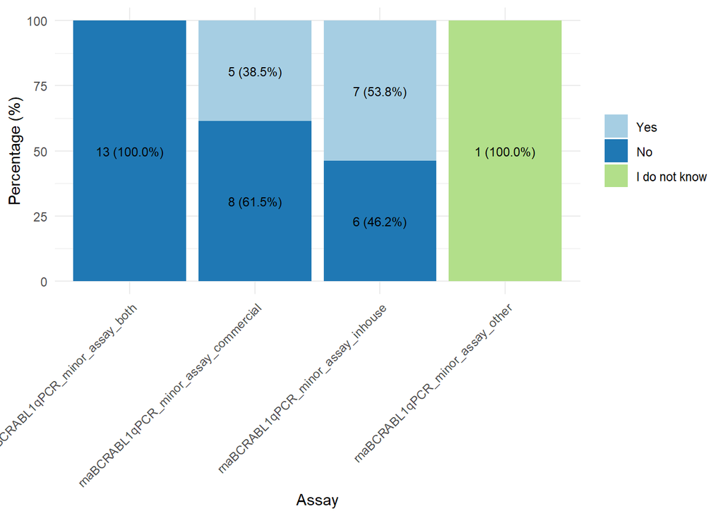

| Category | Comment |
| --- | --- |
| Commercial | Ipsogen BCR::ABL1 m-bcr Kit |
| Commercial | Cepheid |
| Commercial | Qiagene |
| Commercial | commercial for CML |
| In-house | in house for MRD in Ph+ ALL |
| In-house | EAC Priimer- Probe Set |

# 20 Technical Requirements DNA-based BCR::ABL1 ddPCR

no responses

# 21 Technical Requirements RNA-based BCR::ABL1 ddPCR

no responses

Statement 44: For BCR::ABL1-based MRD assessment, RNA is the preferred analysis material.

# 22 Technical requirements STIL::TAL1 qPCR

## 22.1 Which anticoagulant do you use for bone marrow samples intended for STIL::TAL1-based qPCR MRD analysis?

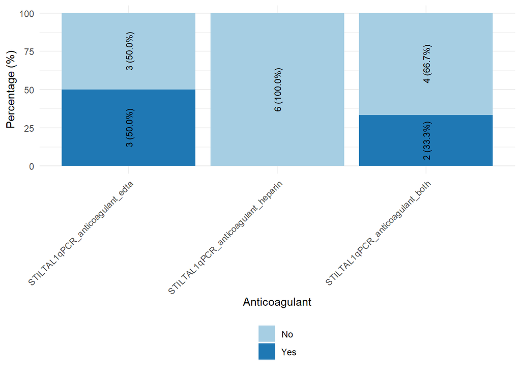

## 22.2 What is the minimum DNA amount you typically analyze?

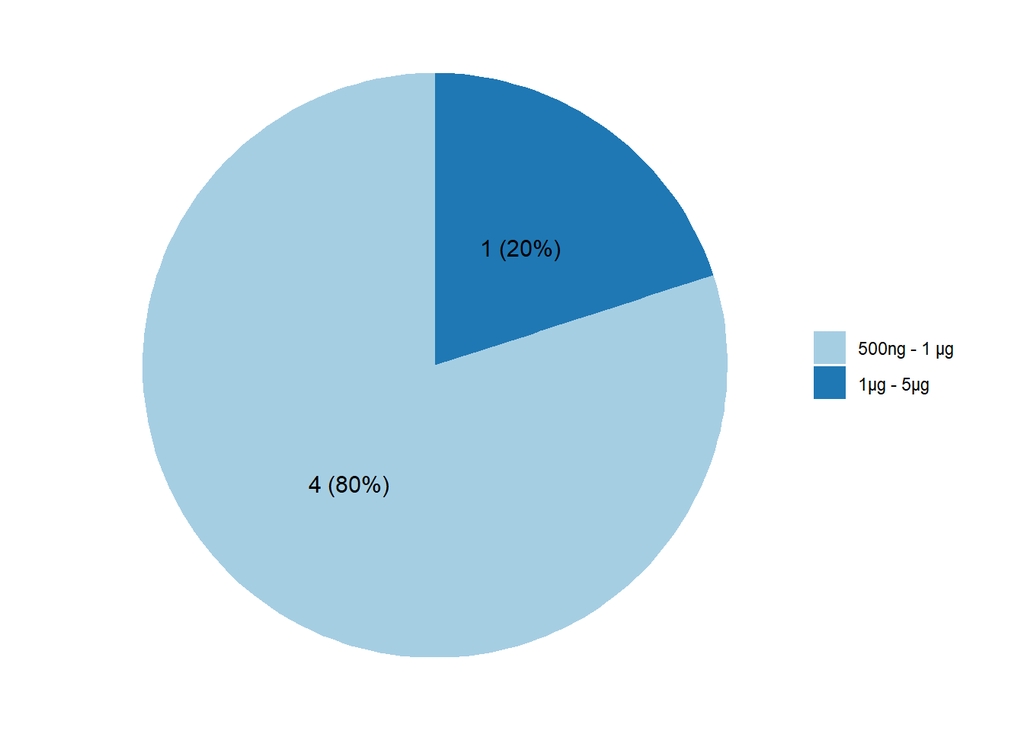

| Category | Comment |
| --- | --- |
| NA | Auswahl im Referenzlabor Kiel |

## 22.3 What level of sensitivity is typically achieved in your MRD analysis?

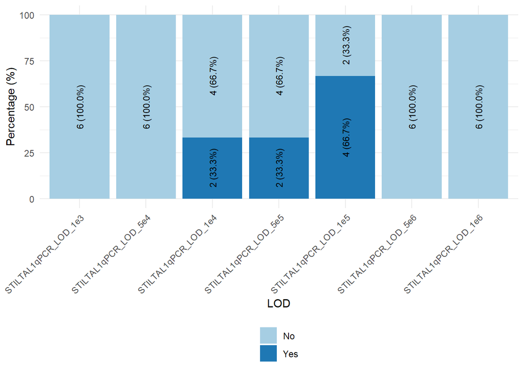

## 22.4 What quantitative range is typically achieved in your MRD analysis?

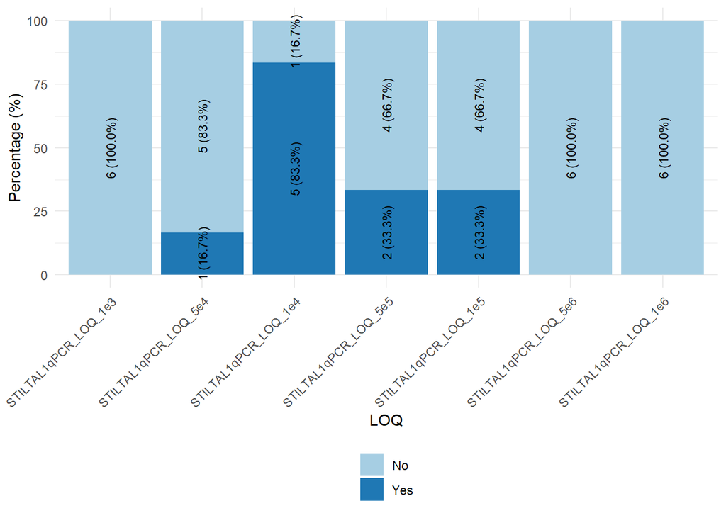

## 22.5 Do you account for background noise from healthy cells in your MRD analysis?

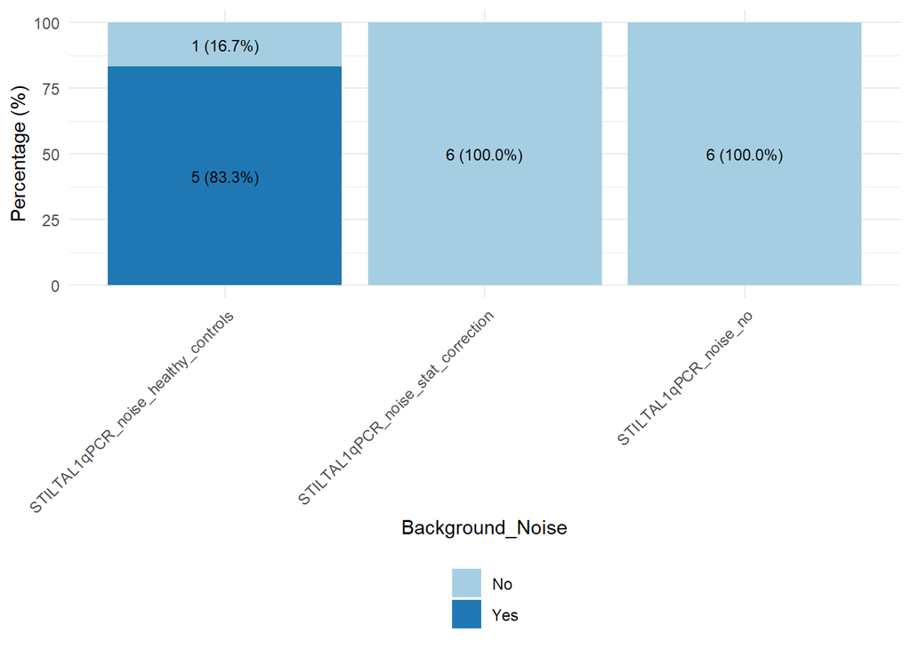

## 22.6 Do you use a commercial assay or an in-house assay for your MRD analysis?

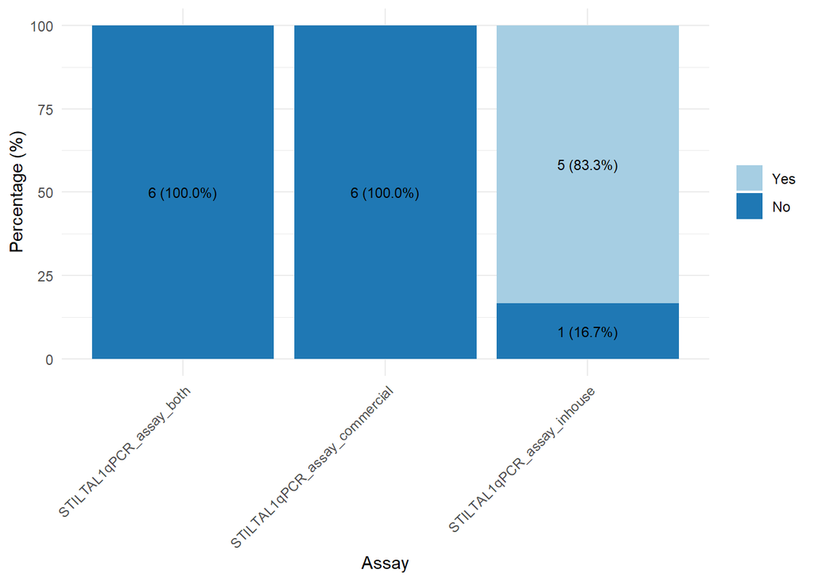

```
## No comments available.
```

# 23 Technical requirements STIL::TAL1 ddPCR

no responses

# 24 Molecular MRD markers

## 24.1 How do you manage patients who do not have a suitable molecular MRD marker?

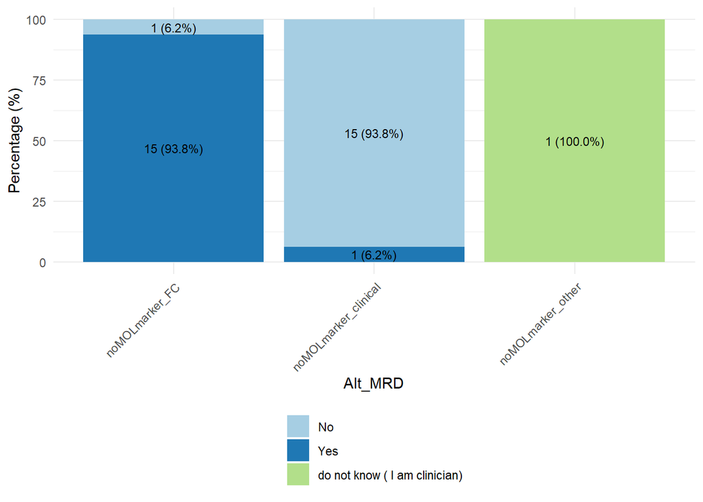

# 25 Prioritization in cases with multiple MRD results

Statement 45: In BCR::ABL1-negative, KMT2A-negative BCP-ALL, IG/TR rearrangements are the preferred MRD markers.

Statement 46: In T-ALL, IG/TR rearrangements are the preferred MRD markers; if these are absent, flow cytometry is the preferred method for MRD assessment.

## 25.1 If both BCR::ABL1-based MRD **on a DNA-level** and IG/TR-based MRD results are available, which one do you prioritize for reporting?

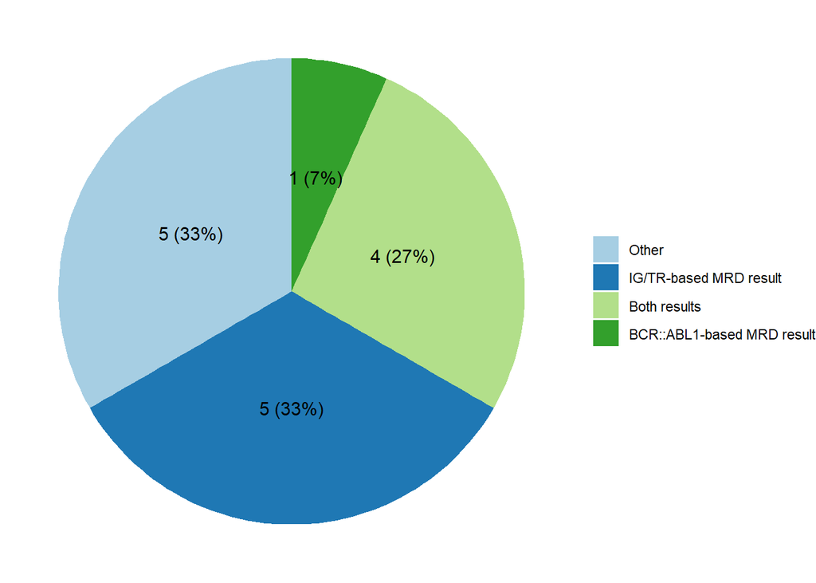

| Category | Comment |
| --- | --- |
| Other | do not use DNA for BCR-ABL |
| Other | only IG/TR performed |
| Other | We do not perform BCR::ABL1-based DNA MRD. However, in case such result was available, both results would be reported from the lab to the clinicians. The concordance or discordance of results and fina… |
| Other | do not use IG/TR-MRD |
| Other | BCR::ABL1 is not used for stratification |

## 25.2 If both BCR::ABL1-based MRD **on an RNA-level** and IG/TR-based MRD results are available, which one do you prioritize for reporting?

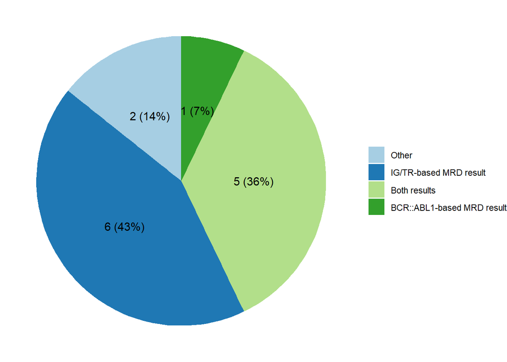

| Category | Comment |
| --- | --- |
| Other | Both results are reported from the lab to the clinicians. The concordance or discordance of results and final conclusions are discussed in a multidisciplinary meeting for every MRD assessment for all … |
| Other | do not use IG/TR-MRD |
| IG/TR-based MRD result | BCR::ABL1 is not used for stratification |

Statement 47: In BCR::ABL1-positive BCP-ALL, BCR::ABL1-positivity should be confirmed by an IG/TR marker to exclude the possibility that BCR::ABL1 is present in a different cell compartment.

## 25.3 If both KMT2A-based MRD and IG/TR-based MRD results are available, which one do you prioritize for reporting?

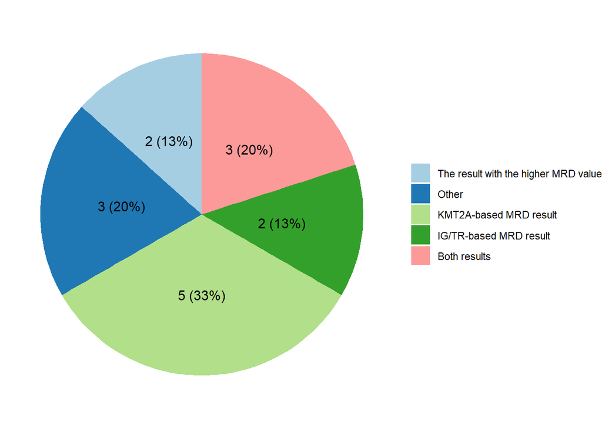

| Category | Comment |
| --- | --- |
| Other | We do not perform KMT2A-based MRD. However, in case such result was available, both results would be reported from the lab to the clinicians. The concordance or discordance of results and final conclu… |
| Other | do not use IG/TR-MRD |
| Other | Referenzlabor Kiel legt fest |

Statement 48: In KMT2A-positive BCP-ALL, KMT2A is the preferred MRD marker, as it is less frequently affected by clonal evolution compared to IG/TR markers.

## 25.4 In switch ALL cases, which MRD method do you prioritize for reporting?

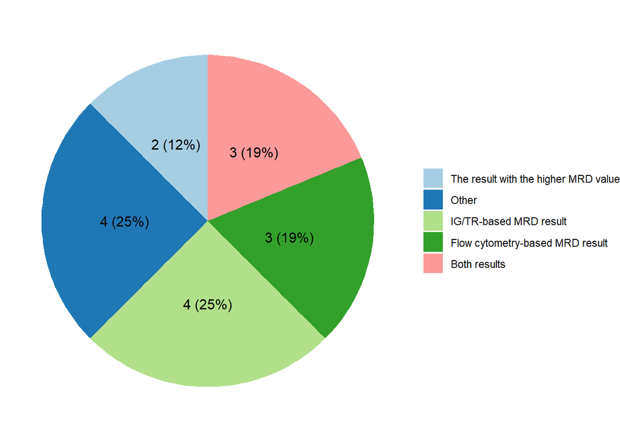

| Category | Comment |
| --- | --- |
| Other | both results with comment from FC group |
| Other | Both results are reported from the lab to the clinicians. The concordance or discordance of results and final conclusions are discussed in a multidisciplinary meeting for every MRD assessment for all … |
| Other | in the US all results have to be reported if a clinical test. Protocols can give guidance and local institutions have their own standard. But it is not allowed for the lab who performs the assay to pr… |
| Other | Referenzlabor Kiel legt fest |

# 26 MRD vs. cytomorphology for remission assessment

> MRD and cytomorphology results are not always concordant. In the following situations, which value do you choose for clinical reporting to state the blast percentage at the time of remission assessment?

## 26.1 Cytomorphology >25% and:

### 26.1.1 MRD <1%

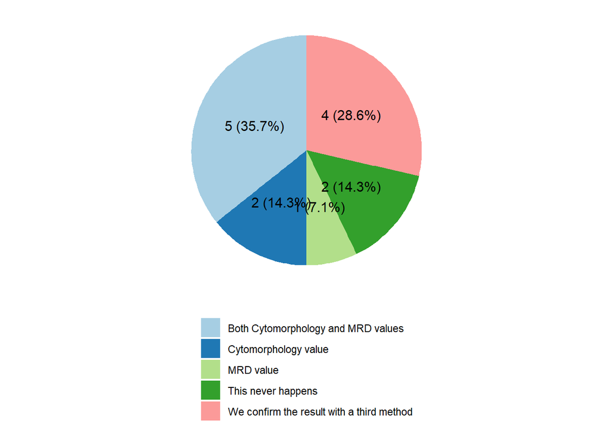

### 26.1.2 MRD 1-5%

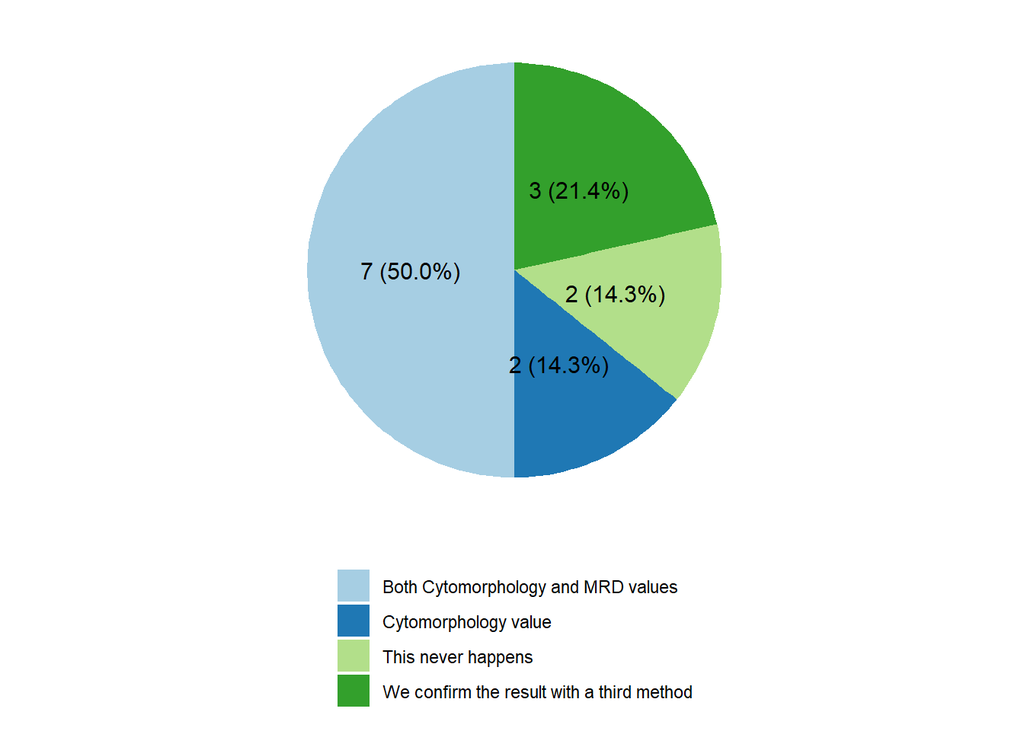

### 26.1.3 MRD 5-25%

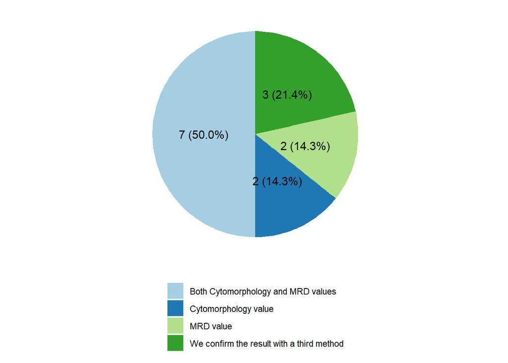

### 26.1.4 MRD >25%

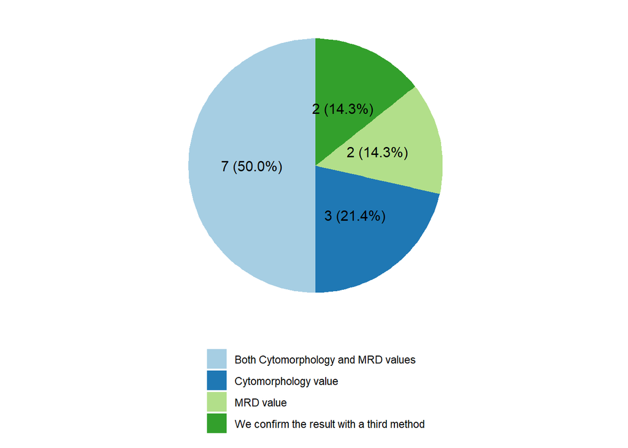

## 26.2 Cytomorphology 5-25% and:

### 26.2.1 MRD <1%

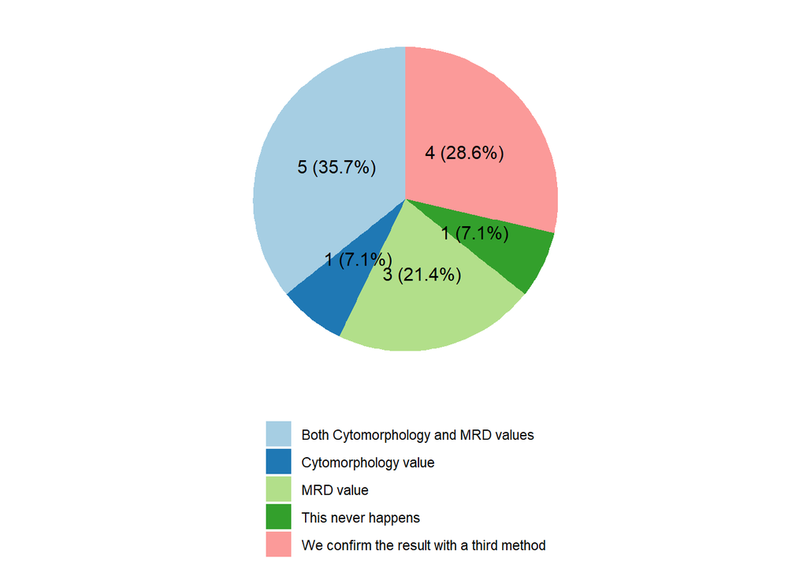

### 26.2.2 MRD 1-5%

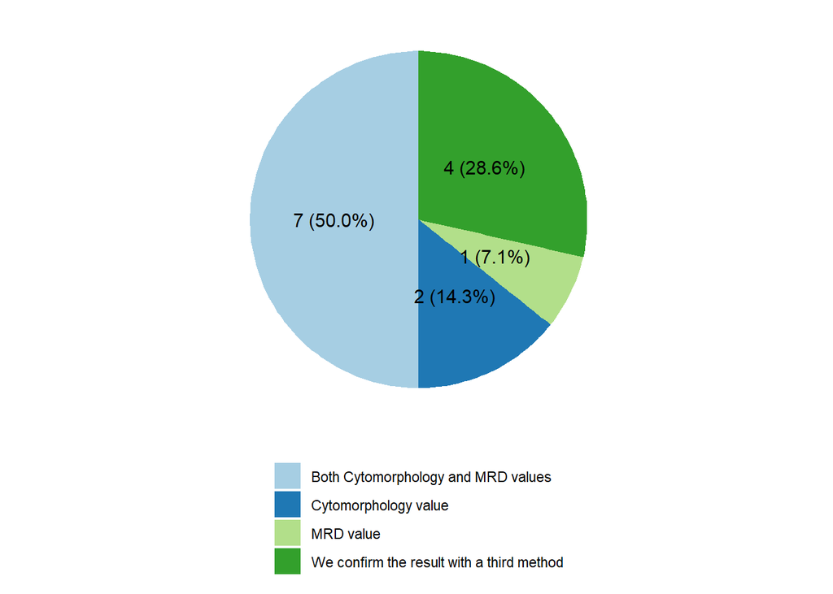

### 26.2.3 MRD 5-25%

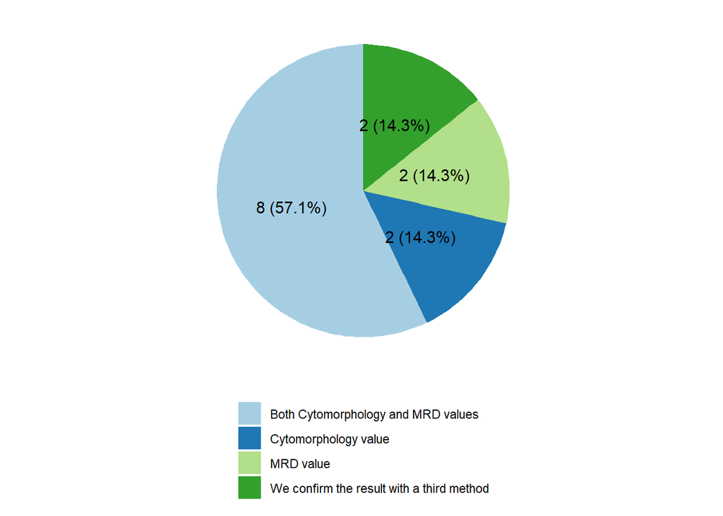

### 26.2.4 MRD >25%

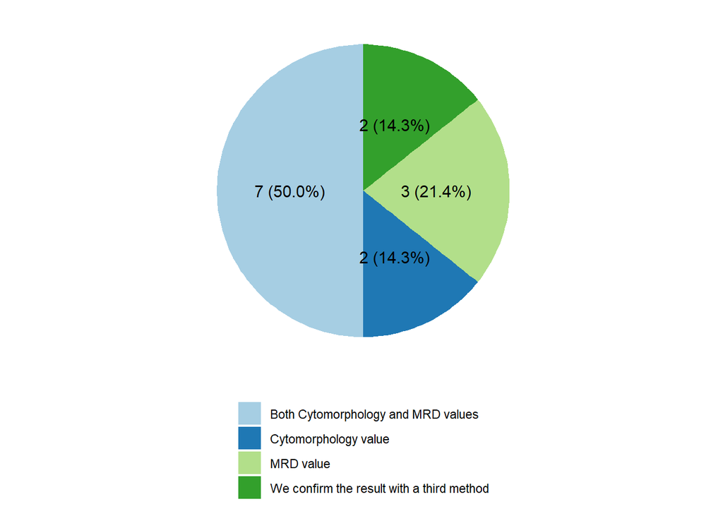

## 26.3 Cytomorphology <5% and:

### 26.3.1 MRD <1%

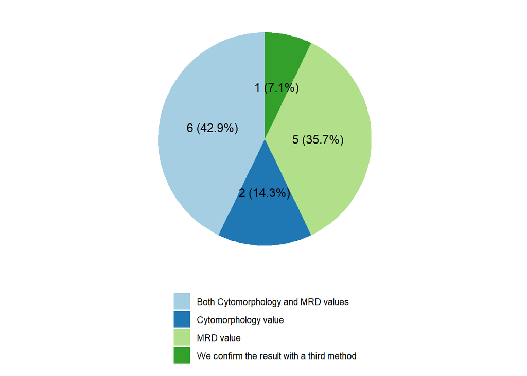

### 26.3.2 MRD 1-5%

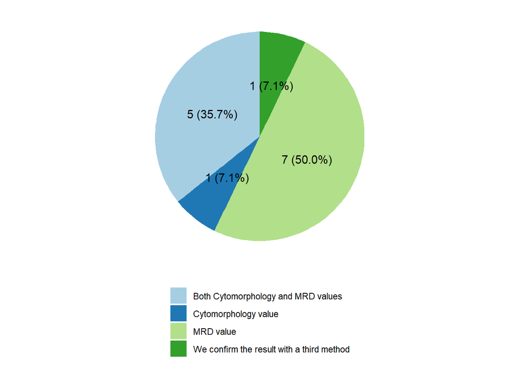